# Association, prediction and regulatory evidence

B13: Reusable teaching module

## Learning objectives

Define marker dosage and phenotype contrasts; identify confounding and linkage disequilibrium; distinguish GWAS, eQTL, TWAS, fine-mapping and prediction.

## 1. Biological question and measurements

GWAS evaluates association between variants and a phenotype. An eQTL analysis evaluates association between variants and expression. TWAS uses expression-related genetic information in a trait-association framework. These approaches connect measurements, but none automatically identifies a causal variant, causal gene or mediation mechanism.

Relatedness and population structure can induce association when genetic groups differ in environment or phenotype. Linkage disequilibrium allows a marker to tag nearby variation; multiple correlated associations need not imply multiple mechanisms. Fine-mapping compares candidate explanations under an explicit model and requires appropriate LD, coverage, allele alignment and prior assumptions. A posterior probability is conditional on that model and supplied candidates.

Genomic prediction evaluates the ability to predict new animals, rather than selecting the smallest association p-value. The deployment population and training relationships determine the relevant validation design.

## 2. Model and assumptions

A basic unrelated-sample model is $y_i=\beta_0+\beta_g g_i+\gamma^T c_i+e_i$, where $g_i$ counts a stated allele and c contains prespecified covariates. Residual independence and the design matter. With correlated relatives, a mixed-model or other suitable framework is needed.

For two marker vectors, their correlation describes association of the supplied dosages. It does not establish ancestry, phase, a causal allele or a calibrated fine-mapping probability.

## 3. Worked example

The inputs below are hypothetical. Run the example, predict one change, then compare your prediction with the result. All executable code uses base R.

**Show R code**

```r
set.seed(1301)
ancestry <- rep(c(0,1),each=20)
g <- rbinom(40,2,ifelse(ancestry==0,.2,.8))
y <- 3*ancestry+rnorm(40)
unadjusted <- lm(y~g)
adjusted <- lm(y~g+ancestry)
c(unadjusted_marker=coef(unadjusted)["g"],adjusted_marker=coef(adjusted)["g"])
```

```
unadjusted_marker.g   adjusted_marker.g
         1.44495380         -0.02545743
```

**Show R code**

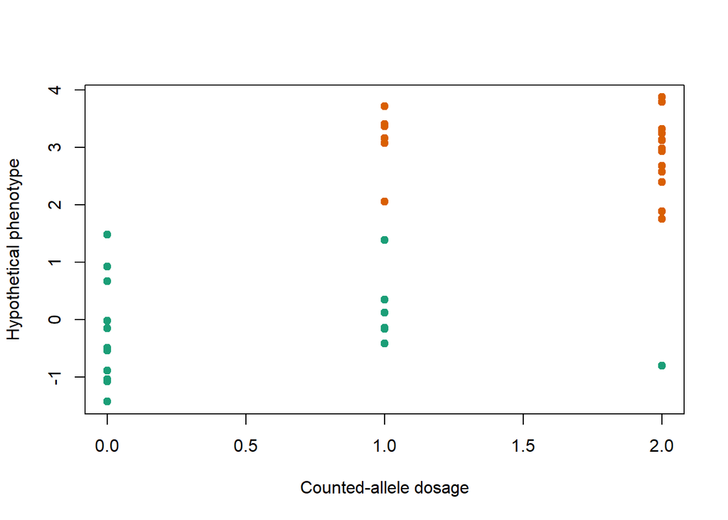

```r
stopifnot(qr(model.matrix(adjusted))$rank==3)
plot(g,y,col=ifelse(ancestry==0,"#1b9e77","#d95f02"),pch=19,
 xlab="Counted-allele dosage",ylab="Hypothetical phenotype")
```

The generating model contains no direct marker effect. Group differences can nevertheless create a marginal marker association. One realization does not make the adjusted estimate exactly zero.

## 4. Interpretation and scope

Adjustment can reduce specified confounding but cannot guarantee that all confounding has been measured. Do not infer causality from conditional association, a TWAS signal or agreement between assays. Fit and validate appropriate models before applying any teaching formula to related livestock data.

## 5. Exercises

1. Why can a variant associate with a trait without changing it?
2. What is the eQTL response variable?
3. Why can randomly splitting relatives exaggerate deployment performance?

**Suggested answers**

1. LD with causal variation or association with ancestry/environment can produce the signal.
2. A specified expression measurement in a stated tissue/context.
3. Close relatives in training and test can make the task easier than prediction in a new family or population.

## Practicals and course pathways

Association and regulatory variation (in development), trait association (in development) and prediction (in development).

Use the unified map to locate B13 in both harmonized outlines. Return to the building-block index.